# Project Python Foundations: FoodHub Data Analysis

### **Question 7**: Which are the top 5 restaurants in terms of the number of orders received? [1 mark]

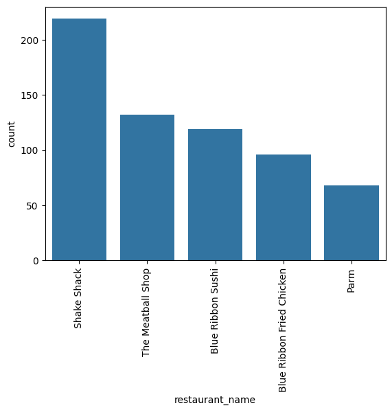

```python
# Write the code here
df_top_restaurants= df.groupby(df.restaurant_name).order_id.count()\
.reset_index(name='count') \
.sort_values(['count'], ascending=False)\
.head(5)

plt.xticks(rotation=90)

sns.barplot(data = df_top_restaurants, x='restaurant_name'
, y='count')
plt.show()
```

#### Observations:

Shake Shack has received 219 order and then meat ball shop and blue ribbon sushi ranked at top3

### **Question 8**: Which is the most popular cuisine on weekends? [1 mark]

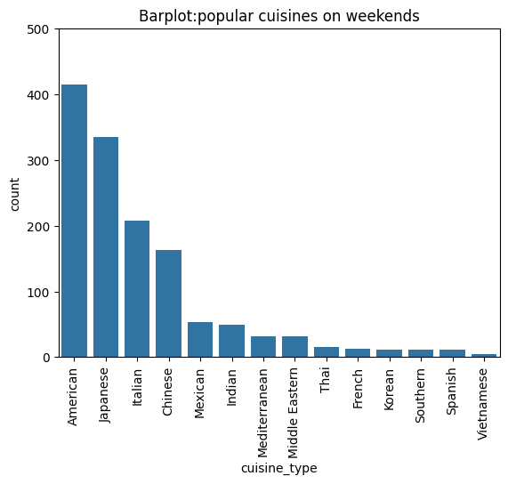

```python
# Write the code here
df_pop_cusine_weekends = df.loc[df['day_of_the_week'] == 'Weekend']\
.groupby([df.cuisine_type]).cuisine_type.count()\
.reset_index(name='count')\
.sort_values(['count'],ascending=False)
df_pop_cusine_weekends
plt.xticks(rotation=90)
plt.title('Barplot:popular cuisines on weekends')
plt.ylim(0,500)
sns.barplot(data=df_pop_cusine_weekends,x='cuisine_type', y='count')
```

#### Observations:

Amrican, Japanese, Italian and chinese, Mexican are the top 5 cusines in the weekend orders

### **Question 9**: What percentage of the orders cost more than 20 dollars? [2 marks]

```python
# Write the code here
round(df.loc[df['cost_of_the_order'] > 20].order_id.count() / df.order_id.count() * 100 ,2)
```

```
29.24
```

#### Observations:

29.24% of ordres out of 1898 orders are cost more than 20$

### **Question 10**: What is the mean order delivery time? [1 mark]

```python
# Write the code here
print(df.delivery_time.describe(include='all').transpose()['mean'])
df.delivery_time.mean()
```

```
24.161749209694417
```

```
24.161749209694417
```

#### Observations:

24.161749, can derive the values in two ways but the second approach seems more appropriate

### **Question 11:** The company has decided to give 20% discount vouchers to the top 3 most frequent customers. Find the IDs of these customers and the number of orders they placed. [1 mark]

```python
# Write the code here
df.groupby(df.customer_id).customer_id.count()\
.reset_index(name='count')\
.sort_values(['count'],ascending=False).head(3)
```

|  | customer_id | count |
| --- | --- | --- |
| 116 | 52832 | 13 |
| 84 | 47440 | 10 |
| 333 | 83287 | 9 |

#### Observations:

The top 3 cust_ids based on their previous # of orders

### **Question 12**: Perform a multivariate analysis to explore relationships between the important variables in the dataset. (It is a good idea to explore relations between numerical variables as well as relations between numerical and categorical variables) [10 marks]

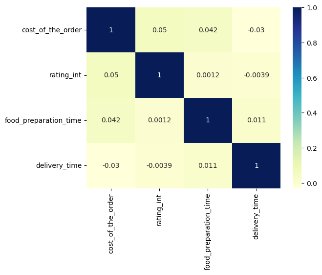

```python
# Write the code here
df['rating_int'] = df.rating.astype(int)
sns.heatmap(data=df[['cost_of_the_order','rating_int','food_preparation_time','delivery_time']].corr(), annot=True, cmap='YlGnBu');
```

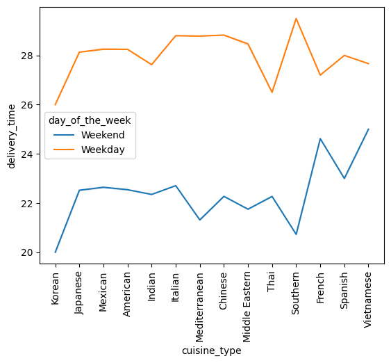

```python
plt.xticks(rotation=90)
sns.lineplot(data = df , x = 'cuisine_type' , y = 'delivery_time', hue = 'day_of_the_week', errorbar=('ci', False))
```

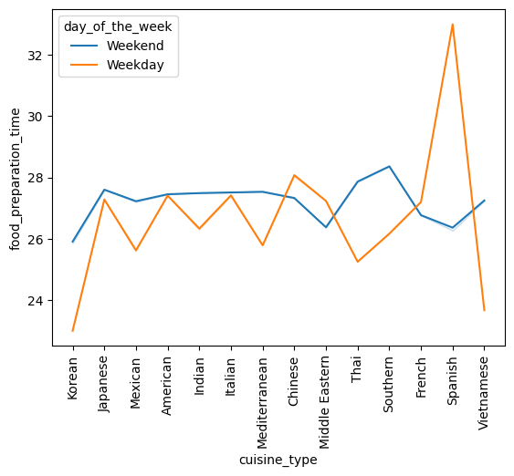

```python
plt.xticks(rotation=90)
sns.lineplot(data = df , x = 'cuisine_type' , y = 'food_preparation_time', hue = 'day_of_the_week', errorbar=('ci', False))
```

Seems spanish cuisine is taking more to prepare food for the order

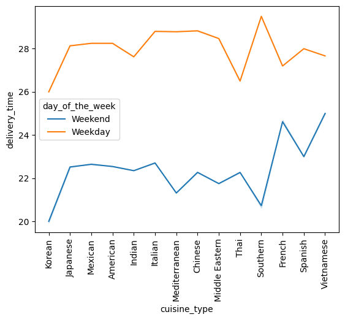

```python
plt.xticks(rotation=90)
sns.lineplot(data = df , x = 'cuisine_type' , y = 'delivery_time', hue = 'day_of_the_week', errorbar=('ci', False))
```

**Observation** Delivery time is more on weekdays than weekend, it may be due to traffic condiotons on road

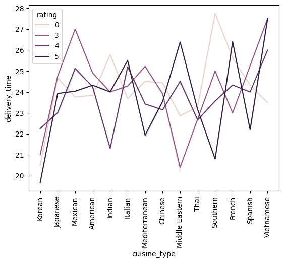

```python
plt.xticks(rotation=90)
sns.lineplot(data = df , x = 'cuisine_type' , y = 'delivery_time', hue = 'rating', errorbar=('ci', False))
```

**Observation** It seems delivery time and rating has low impact

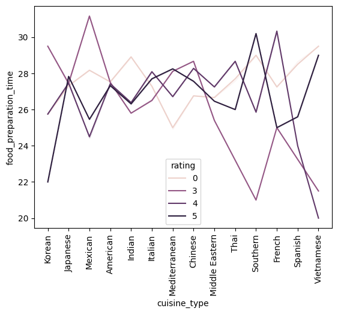

```python
plt.xticks(rotation=90)
sns.lineplot(data = df , x = 'cuisine_type' , y = 'food_preparation_time', hue = 'rating', errorbar=('ci', False))
```

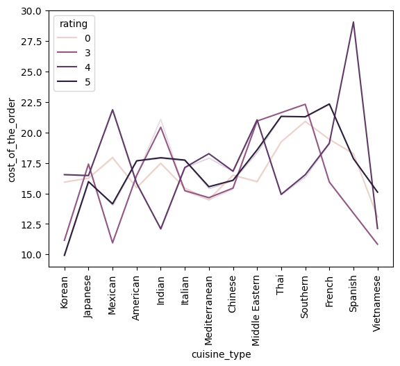

```python
plt.xticks(rotation=90)
sns.lineplot(data = df , x = 'cuisine_type' , y = 'cost_of_the_order', hue = 'rating', errorbar=('ci', False))
# sns.histplot(data=df, x='cuisine_type', hue='rating', kde=True);
```

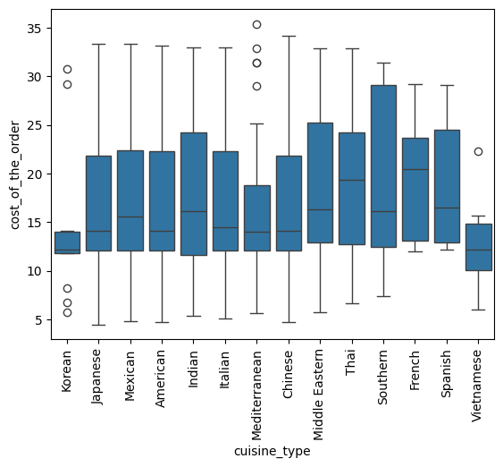

```python
# average cost of orders
plt.xticks(rotation=90)
sns.boxplot(data=df, x='cuisine_type', y='cost_of_the_order') ;
```

Observation: most of the orders are 14 dollar and most of the orders costs are more than 14 dollars outliers on mediteranean and koream

[figure not shown]

```python
sns.catplot(data=df, x="rating", y="cost_of_the_order", hue="day_of_the_week", col="cuisine_type", kind='box', palette='bright');
```